# Regresión LS

Curso R

11 de marzo de 2020

# Regresión lineal simple

Estos modelos suponen relaciones causales de una variable explicativa sobre una variable explicada las cuales pueden ser relacionadas con la siguiente expresión:

$$y_i=\beta_1+\beta_2x_i+\epsilon_i$$
En este caso se pueden estimar los coeficientes de las betas a través de una muestra de los valores de *y* y de *x*

$$\hat{y}_i=\hat{\beta}_1+\hat{\beta}_2x_i$$

De tal forma que

$$y_i=\hat{y}_i+\hat{\epsilon}_i$$

Finalmente

$$y_i=\hat{\beta}_1+\hat{\beta}_2x_i+\hat{\epsilon}_i$$

Lo que se plantea en la práctica es

$$min_{\hat{\beta}_1,~\hat{\beta_2}}\sum\hat{\epsilon}^2$$

Lo que da como resultado

$$\hat{\beta}_2=\frac{n\sum x_iy_i-\sum x_i\sum y_i}{n\sum x_i^2-(\sum x_i)^2}$$

Ejemplo empírico

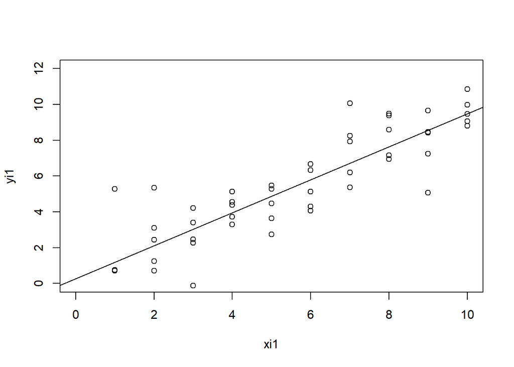

```r
fac<-1.5
xi1<-rep(c(1:10), each=5)
yi1<-xi1+rnorm(50)*fac

plot(yi1~xi1, xlim=c(0,10), ylim=c(0,12))

ml1<-lm(yi1~xi1)
abline(ml1)
```

Si deseamos saber cuánto valen $\hat{\beta}_1=$ 0.2696496 y $\hat{\beta}_2=$ 0.9216147

Para una segunda muestra con el mismo tamaño, estos serían los resultados

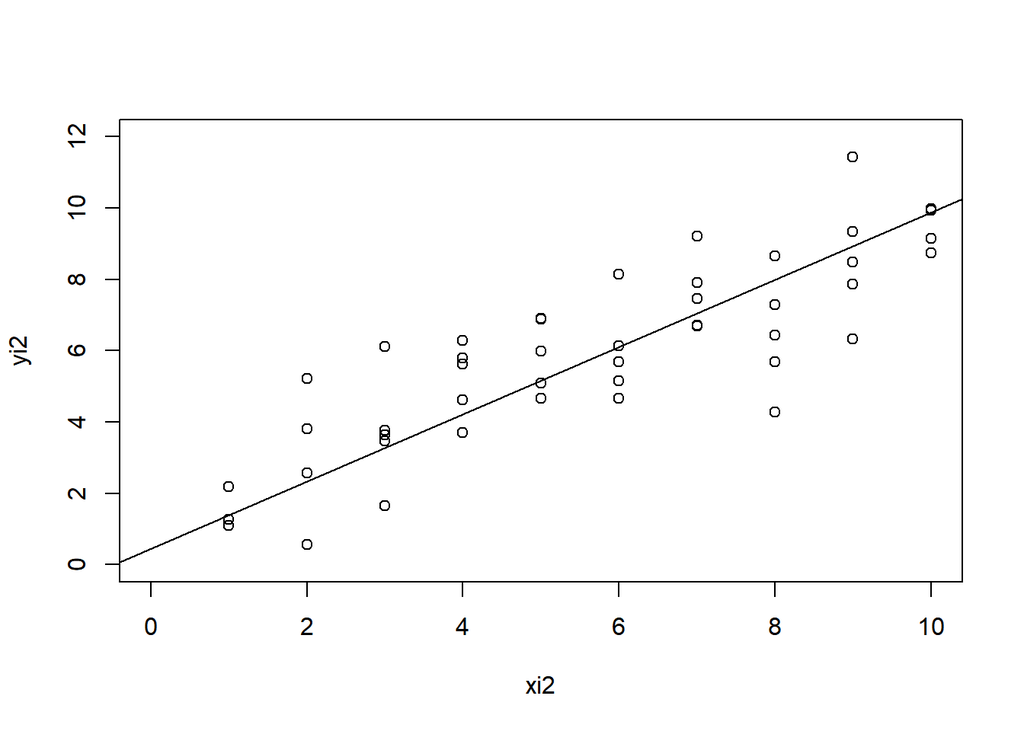

```r
xi2<-rep(c(1:10), each=5)
yi2<-xi2+rnorm(50)*fac

plot(yi2~xi2, xlim=c(0,10), ylim=c(0,12))

ml2<-lm(yi2~xi2)
abline(ml2)
```

Si deseamos saber cuánto valen $\hat{\beta}_1=$ 0.449595 y $\hat{\beta}_2=$ 0.9438415

Comparando

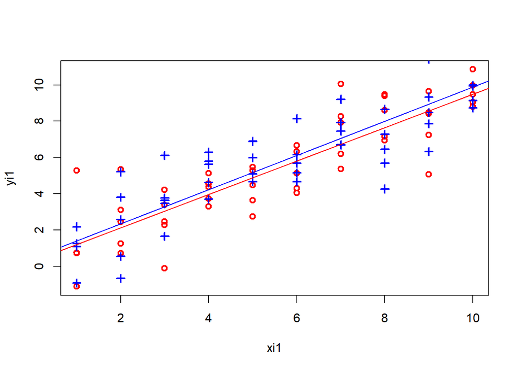

```r
plot(yi1~xi1, col = "red", lwd = 2, pch=1)
points(yi2~xi2, col = "blue", lwd = 2, pch=3)
abline(ml1, col="red")
abline(ml2, col="blue")
```

En realidad la recta poblacional sería:

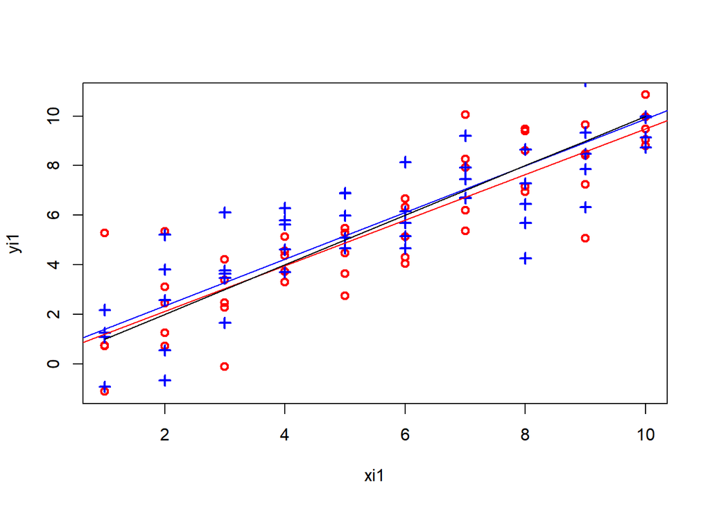

```r
plot(yi1~xi1, col = "red", lwd = 2, pch=1)
points(yi2~xi2, col = "blue", lwd = 2, pch=3)
abline(ml1, col="red")
abline(ml2, col="blue")
lines(c(1:10)~c(1:10))
```

Se puede apreciar una sobrestimación y subestimación de las rectas muestrales comparadas con la poblacional.

## Análisis estadístico del modelo ml1

```r
sml1<-summary(ml1)
sml1
```

```
##
## Call:
## lm(formula = yi1 ~ xi1)
##
## Residuals:
##     Min      1Q  Median      3Q     Max
## -3.5003 -0.6984 -0.1912  0.9329  4.0905
##
## Coefficients:
##             Estimate Std. Error t value Pr(>|t|)
## (Intercept)  0.26965    0.45938   0.587     0.56
## xi1          0.92161    0.07404  12.448   <2e-16 ***
## ---
## Signif. codes:  0 '***' 0.001 '**' 0.01 '*' 0.05 '.' 0.1 ' ' 1
##
## Residual standard error: 1.504 on 48 degrees of freedom
## Multiple R-squared:  0.7635, Adjusted R-squared:  0.7586
## F-statistic:   155 on 1 and 48 DF,  p-value: < 2.2e-16
```

**Normalidad en los errores estimados**

Antes de iniciar las pruebas de hipótesis pertinentes, se debe realizar la prueba de normalidad en los errores.

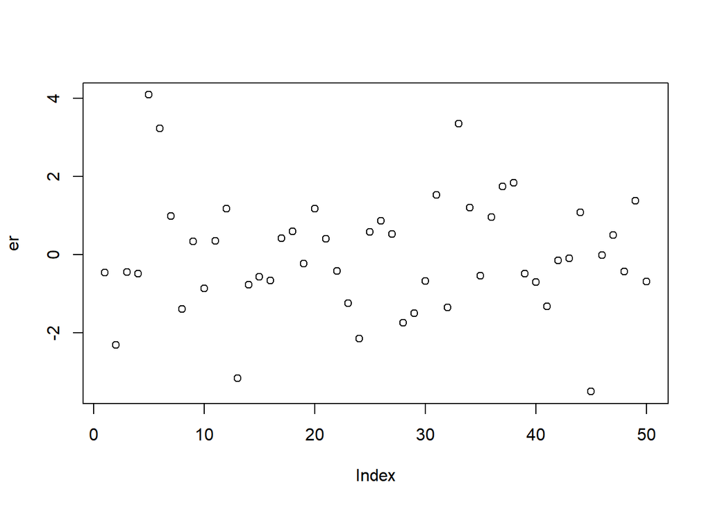

```r
er<-sml1$residuals
plot(er)
```

Estandarización de los errores

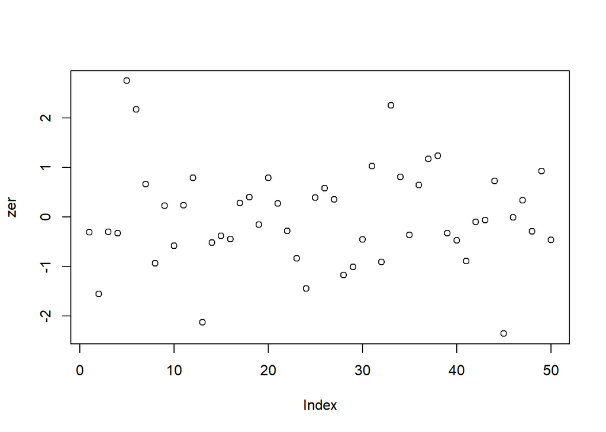

```r
zer<-(er-mean(er))/sd(er)
plot(zer)
```

Prueba de normalidad

```r
jarque.bera.test(zer)
```

```
##
##  Jarque Bera Test
##
## data:  zer
## X-squared = 1.9541, df = 2, p-value = 0.3764
```

Como se puede apreciar el valor **P** del estadístico de la prueba proporciona suficiente evidencia para no rechazar normalidad en los errores.

**Estadístico F**

El estadístico de F de Fisher sirve para probar las siguientes hipótesis:

$H_0:~\beta_1=\beta_2=0$

$H_A:~Alguna~\beta_i\neq0$

```r
Fish<-pf(sml1$fstatistic[1],sml1$fstatistic[2],sml1$fstatistic[3],lower.tail = F)
```

Para el ejemplo en cuestión la el valor **P** de la *F de Fisher* es de 1.222199510^{-16}, por lo que existe suficiente evidencia para rechazar $H_0$

**¿Qué pasa si es la $\beta_1$ la que es diferente de cero?**

**Estadístico t de estudent**

En este caso se plantean las hipótesis individuales para cada coeficiente beta estimado.

$H_0:~\beta_1=0$

$H_A:~\beta_1\neq0$

y

$H_0:~\beta_2=0$

$H_A:~\beta_2\neq0$

```r
sml1$coef
```

```
##              Estimate Std. Error    t value     Pr(>|t|)
## (Intercept) 0.2696496 0.45938353  0.5869813 5.599671e-01
## xi1         0.9216147 0.07403636 12.4481360 1.222200e-16
```

En este caso se observa que el valor **P** 0.5599671 para la $\beta_1$ es mayor que un nivel de significancia propuesto del 0.05 por lo que o existe evidencia para rechazar $H_0$, caso contrario a $\beta_2$ en el cual el valor __P__1.222199510^{-16} es menor, por lo que existe suficiente evidencia para rechazar $H_0$

**Coeficiente de determinación ajustado**

```r
sml1$adj.r.squared
```

```
## [1] 0.7585685
```

**Coeficientes del Modelo**

```r
ml1$coefficients
```

```
## (Intercept)         xi1
##   0.2696496   0.9216147
```

# Ejemplo Práctico

```r
library(readxl)
Encuesta <- read_excel("Encuesta.xlsx")
View(Encuesta)
```

Estos son datos de las calificaciones de alumnos a nivel bachillerato y sus calificaciones obtenidas a nivel licenciatura al momento de la encuesta, la idea es demostrar si las calificaciones de su licenciatura es una variable causada por las calificaciones obtenidas en el bachillerato

```r
table(Encuesta$promact)
```

```
##
##    7  7.4  7.5  7.6  7.8 7.89  7.9 7.95    8  8.1  8.2 8.22 8.24  8.3  8.4 8.47
##    2    3    1    5    4    1    5    1   13    7    5    1    1    3    6    1
##  8.5 8.53  8.6  8.7 8.87  8.9 8.92    9  9.1  9.2 9.27  9.3  9.5 9.56  9.6
##    1    1    2    1    1    4    1    6    2    5    1    1    1    1    1
```

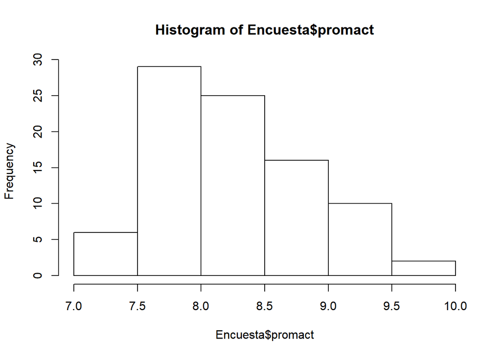

```r
hist(Encuesta$promact)
```

```r
table(Encuesta$prombach)
```

```
##
##  7.2  7.3  7.5  7.6  7.8  7.9    8 8.02  8.1  8.2  8.3 8.36  8.4 8.44  8.5  8.6
##    1    1    1    2    1    3    9    1    1    3    3    1    2    1    7    5
##  8.7  8.8 8.84  8.9    9 9.03 9.05  9.1 9.13  9.2 9.25  9.3  9.4 9.45  9.5  9.6
##    2    1    1    4    5    1    1    2    1    5    1    3    2    3    4    3
##  9.7  9.8  9.9
##    1    5    1
```

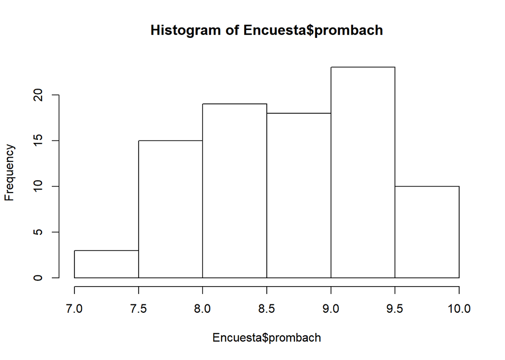

```r
hist(Encuesta$prombach)
```

```r
cor(Encuesta$promact, Encuesta$prombach)
```

```
## [1] 0.5871873
```

Se ejecuta el modelo

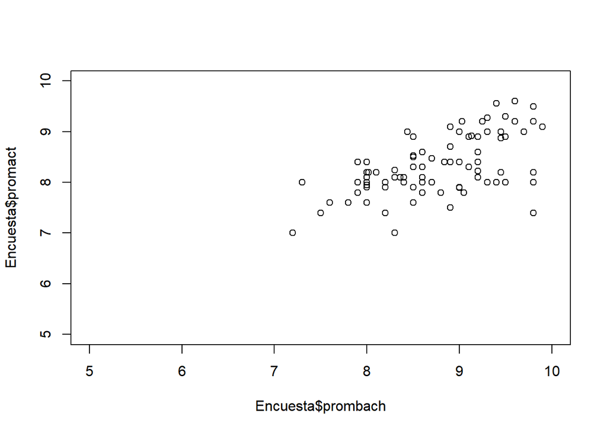

```r
plot(Encuesta$promact~Encuesta$prombach,
     xlim=c(5,10), ylim=c(5,10))
```

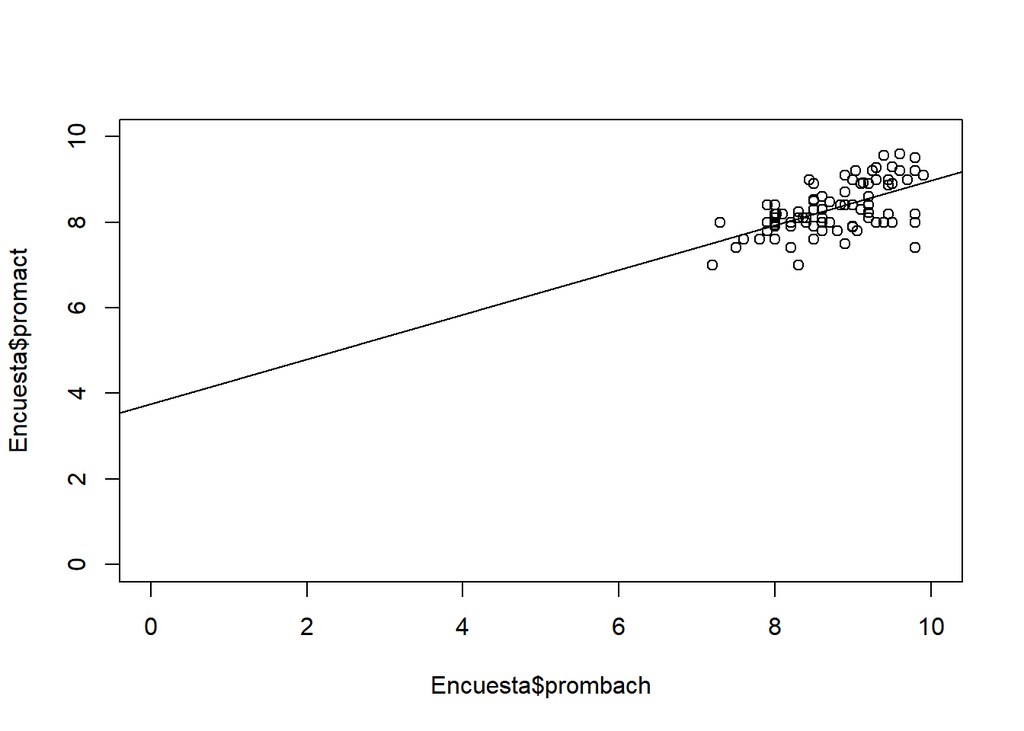

```r
mlc<-lm(promact~prombach, data=Encuesta)

plot(Encuesta$promact~Encuesta$prombach,
     xlim=c(0,10), ylim=c(0,10))
abline(mlc)
```

```r
smlc<-summary(mlc)
```

Se aplica prueba de normalidad a los errores

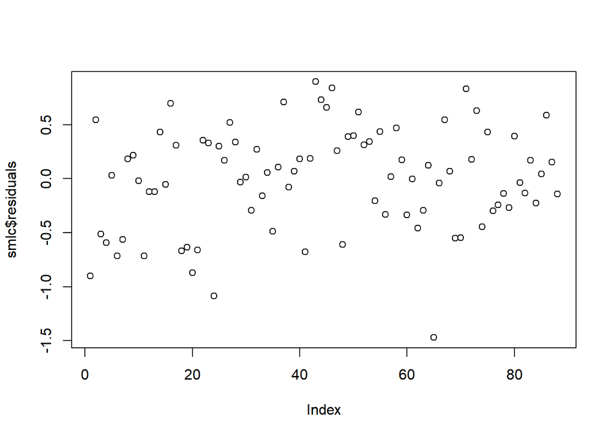

```r
plot(smlc$residuals)
```

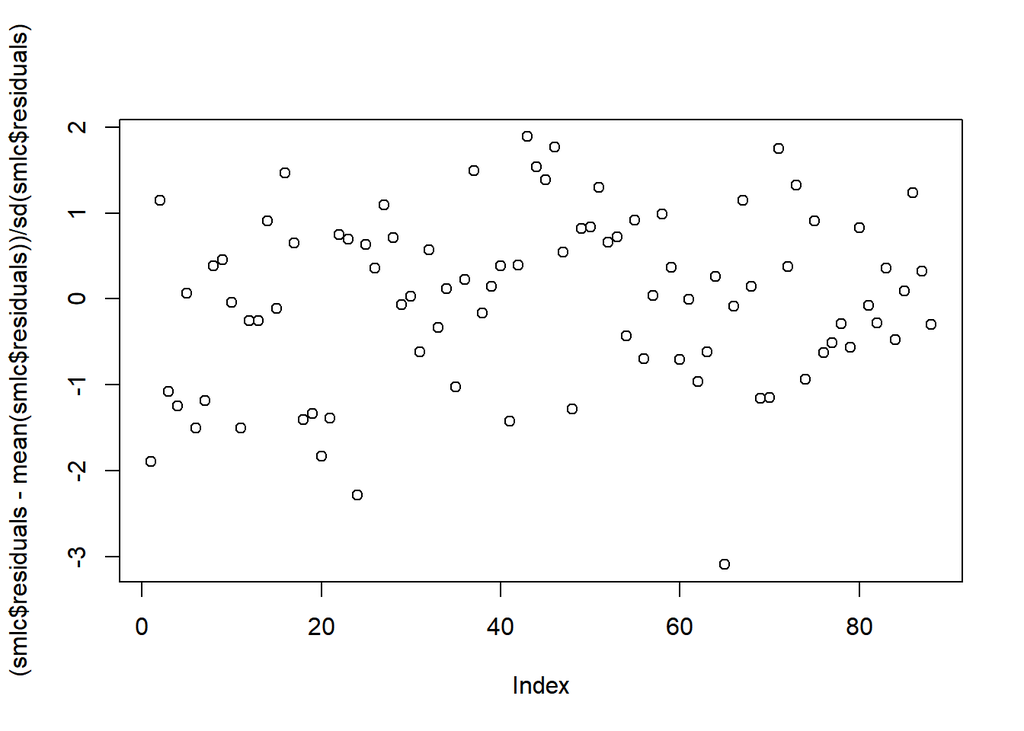

```r
plot((smlc$residuals-mean(smlc$residuals))/sd(smlc$residuals))
```

```r
jarque.bera.test(smlc$residuals)
```

```
##
##  Jarque Bera Test
##
## data:  smlc$residuals
## X-squared = 2.7702, df = 2, p-value = 0.2503
```

Los errores son normales

Se procede a la interpretación

```r
smlc
```

```
##
## Call:
## lm(formula = promact ~ prombach, data = Encuesta)
##
## Residuals:
##     Min      1Q  Median      3Q     Max
## -1.4709 -0.2927  0.0367  0.3395  0.8981
##
## Coefficients:
##             Estimate Std. Error t value Pr(>|t|)
## (Intercept)  3.74944    0.68092   5.506 3.74e-07 ***
## prombach     0.52260    0.07768   6.727 1.82e-09 ***
## ---
## Signif. codes:  0 '***' 0.001 '**' 0.01 '*' 0.05 '.' 0.1 ' ' 1
##
## Residual standard error: 0.4787 on 86 degrees of freedom
## Multiple R-squared:  0.3448, Adjusted R-squared:  0.3372
## F-statistic: 45.26 on 1 and 86 DF,  p-value: 1.82e-09
```

El valor **P** del estadístico **F** de *Fisher* es menor que $\alpha$ por lo que alguna de las betas es diferente de cero.

El valor **P** de los estádisticos **t** de *Student* son menores a $\alpha$, por lo que tanto la pendiente y la orenada al origen son esta´siticamnete diferentes de cero.

El coeficiente de determinación es 0.3372, con lo que podemos decir que el 33.72% de la variación en la calificación a nivel licenciatura se debe a un incrementi en su calificación de su bachillerato, el resto es explicado por eventos aletorios.

El modelo lineal es el siguiente:

$$\hat{PLic}=3.75+.52*PBach$$

En el caso de que el estudiante tenga un promedio de 7 en el bachillerato, su promedio esperado en la licenciatura será

```r
Bach<-7
Lic<-3.75+.52*Bach
Lic
```

```
## [1] 7.39
```